# Leverage deployment guardrails to update a SageMaker Inference endpoint using canary traffic shifting

### We invoke the endpoint during the update operation is in progress.

**Note : Invoke endpoint in this notebook is in single thread mode, to stop the invoke requests please stop the cell execution**

The E's denote the errors generated from the incompatible model version in the canary fleet.

The purpose of the below cell is to simulate errors in the canary fleet. Since the nature of traffic shifting to the canary fleet is probabilistic, you should wait until you start seeing errors. Then, you may proceed to stop the execution of the below cell. If not aborted, cell will run for 600 invocations.

```python
invoke_endpoint(endpoint_name)
```

```
Sending test traffic to the endpoint Deployment-Guardrails-Canary-2023-04-12-21-17-08.
Please wait...
.....................................................................................................................................................................................EEE........EEEE.E.E.....EE..E.E.....EEE.EEE..EEE.EEE.E.EEE..EEE...E.EE.EE....E.....E....E.E....EE..E..E.E.....E..E.....…
Done!
```

[figure not shown]

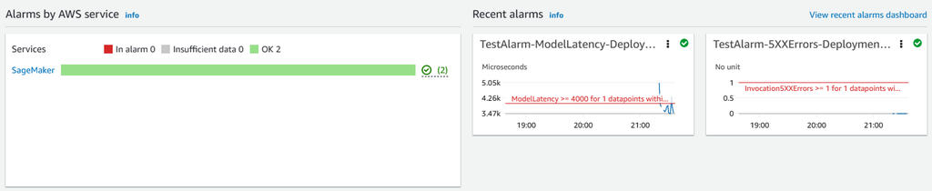

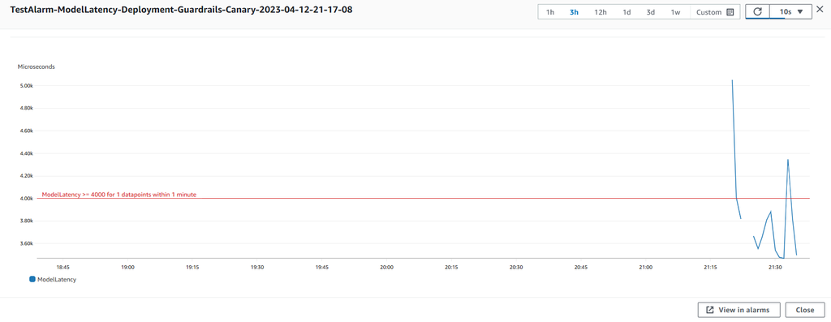

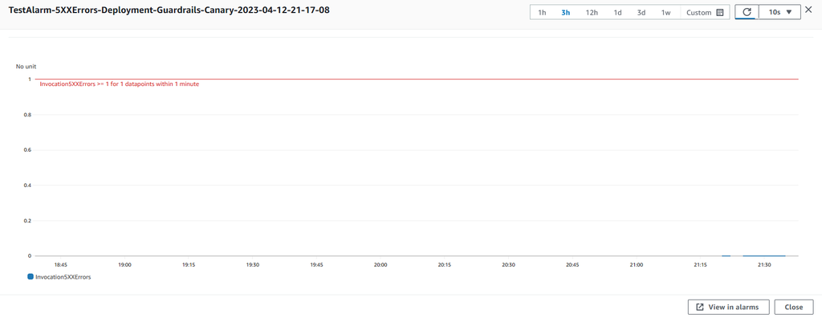

Wait for the update operation to complete and verify the automatic rollback.

```python
wait_for_endpoint_in_service(endpoint_name)

sm.describe_endpoint(EndpointName=endpoint_name)
```

```
Waiting for endpoint in service

Done!
```

```
{'EndpointName': 'Deployment-Guardrails-Canary-2023-04-12-21-17-08',
 'EndpointArn': 'arn:aws:sagemaker:us-east-1:731623272175:endpoint/deployment-guardrails-canary-2023-04-12-21-17-08',
 'EndpointConfigName': 'EpConfig-1-2023-04-12-21-16-52',
 'ProductionVariants': [{'VariantName': 'AllTraffic',
   'DeployedImages': [{'SpecifiedImage': '683313688378.dkr.ecr.us-east-1.amazonaws.com/sagemaker-xgboost:0.90-1-cpu-py3',
     'ResolvedImage': '683313688378.dkr.ecr.us-east-1.amazonaws.com/sagemaker-xgboost@sha256:4814427c3e0a6cf99e637704da3ada04219ac7cd5727ff62284153761d36d7d3',
     'ResolutionTime': datetime.datetime(2023, 4, 12, 21, 17, 9, 219000, tzinfo=tzlocal())}],
   'CurrentWeight': 1.0,
   'DesiredWeight': 1.0,
   'CurrentInstanceCount': 3,
   'DesiredInstanceCount': 3}],
 'EndpointStatus': 'InService',
 'FailureReason': 'One or more configured alarm for automatic rollback deployment is in ALARM state: [TestAlarm-ModelLatency-Deployment-Guardrails-Canary-2023-04-12-21-17-08].',
 'CreationTime': datetime.datetime(2023, 4, 12, 21, 17, 8, 544000, tzinfo=tzlocal()),
 'LastModifiedTime': datetime.datetime(2023, 4, 12, 21, 35, 2, 835000, tzinfo=tzlocal()),
 'LastDeploymentConfig': {'BlueGreenUpdatePolicy': {'TrafficRoutingConfiguration': {'Type': 'CANARY',
    'WaitIntervalInSeconds': 300,
    'CanarySize': {'Type': 'INSTANCE_COUNT', 'Value': 1}},
   'TerminationWaitInSeconds': 120,
   'MaximumExecutionTimeoutInSeconds': 1800},
  'AutoRollbackConfiguration': {'Alarms': [{'AlarmName': 'TestAlarm-5XXErrors-Deployment-Guardrails-Canary-2023-04-12-21-17-08'},
    {'AlarmName': 'TestAlarm-ModelLatency-Deployment-Guardrails-Canary-2023-04-12-21-17-08'}]}},
 'ResponseMetadata': {'RequestId': '33946291-9d60-4e95-8e3b-d62b2022e673',
  'HTTPStatusCode': 200,
  'HTTPHeaders': {'x-amzn-requestid': '33946291-9d60-4e95-8e3b-d62b2022e673',
   'content-type': 'application/x-amz-json-1.1',
   'content-length': '1416',
   'date': 'Wed, 12 Apr 2023 21:40:23 GMT'},
  'RetryAttempts': 0}}
```

Collect the endpoint metrics during the deployment:

Below, we are going to plot graphs to show the Invocations,Invocation5XXErrors and ModelLatency against the Endpoint.

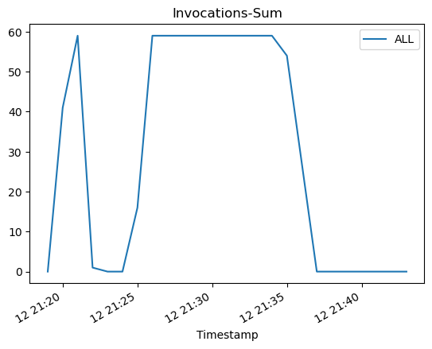

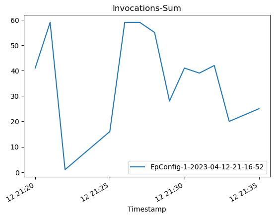

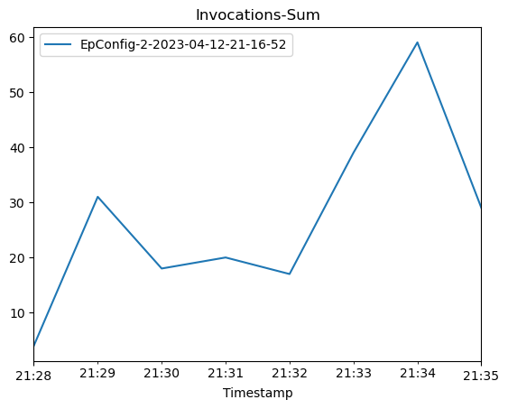

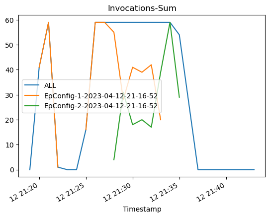

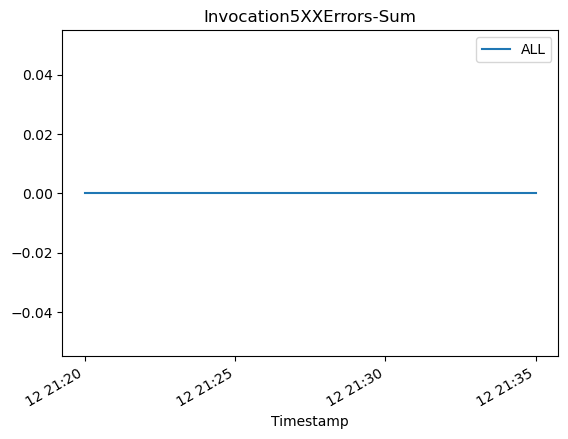

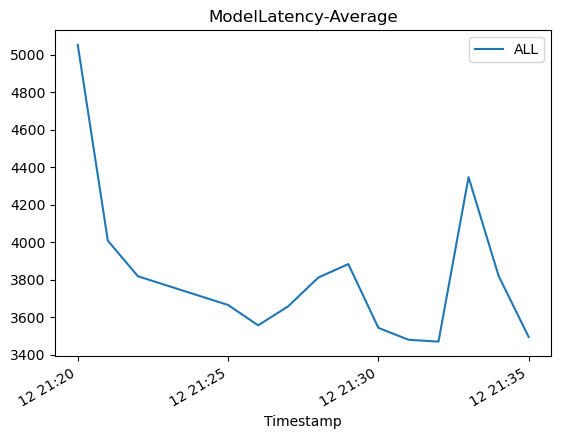

```python
invocation_metrics = plot_endpoint_invocation_metrics(
    endpoint_name, None, "AllTraffic", "Invocations", "Sum"
)
metrics_epc_1 = plot_endpoint_invocation_metrics(
    endpoint_name, ep_config_name, "AllTraffic", "Invocations", "Sum"
)
metrics_epc_2 = plot_endpoint_invocation_metrics(
    endpoint_name, ep_config_name2, "AllTraffic", "Invocations", "Sum"
)

metrics_all = invocation_metrics.join([metrics_epc_1, metrics_epc_2], how="outer")
metrics_all.plot(title="Invocations-Sum")

invocation_5xx_metrics = plot_endpoint_invocation_metrics(
    endpoint_name, None, "AllTraffic", "Invocation5XXErrors", "Sum"
)
model_latency_metrics = plot_endpoint_invocation_metrics(
    endpoint_name, None, "AllTraffic", "ModelLatency", "Average"
)
```

Let's take a look at the Success case where we use the same Canary deployment configuration but a valid endpoint configuration.

### Success Case

[figure not shown]

Now we show the success case where the Endpoint Configuration is updated to a valid version (using the same Canary deployment config as the rollback case).

Update the endpoint with the same Canary deployment configuration:

```python
# update endpoint with a valid version of DeploymentConfig

sm.update_endpoint(
    EndpointName=endpoint_name,
    EndpointConfigName=ep_config_name3,
    RetainDeploymentConfig=True,
)
```

```
{'EndpointArn': 'arn:aws:sagemaker:us-east-1:731623272175:endpoint/deployment-guardrails-canary-2023-04-12-21-17-08',
 'ResponseMetadata': {'RequestId': '018e7ecc-07cc-4890-a489-d9ab3dabec16',
  'HTTPStatusCode': 200,
  'HTTPHeaders': {'x-amzn-requestid': '018e7ecc-07cc-4890-a489-d9ab3dabec16',
   'content-type': 'application/x-amz-json-1.1',
   'content-length': '116',
   'date': 'Wed, 12 Apr 2023 21:47:38 GMT'},
  'RetryAttempts': 0}}
```

```python
sm.describe_endpoint(EndpointName=endpoint_name)
```

```
{'EndpointName': 'Deployment-Guardrails-Canary-2023-04-12-21-17-08',
 'EndpointArn': 'arn:aws:sagemaker:us-east-1:731623272175:endpoint/deployment-guardrails-canary-2023-04-12-21-17-08',
 'EndpointConfigName': 'EpConfig-1-2023-04-12-21-16-52',
 'ProductionVariants': [{'VariantName': 'AllTraffic',
   'DeployedImages': [{'SpecifiedImage': '683313688378.dkr.ecr.us-east-1.amazonaws.com/sagemaker-xgboost:0.90-1-cpu-py3',
     'ResolvedImage': '683313688378.dkr.ecr.us-east-1.amazonaws.com/sagemaker-xgboost@sha256:4814427c3e0a6cf99e637704da3ada04219ac7cd5727ff62284153761d36d7d3',
     'ResolutionTime': datetime.datetime(2023, 4, 12, 21, 17, 9, 219000, tzinfo=tzlocal())}],
   'CurrentWeight': 1.0,
   'DesiredWeight': 1.0,
   'CurrentInstanceCount': 3,
   'DesiredInstanceCount': 3}],
 'EndpointStatus': 'Updating',
 'FailureReason': 'One or more configured alarm for automatic rollback deployment is in ALARM state: [TestAlarm-ModelLatency-Deployment-Guardrails-Canary-2023-04-12-21-17-08].',
 'CreationTime': datetime.datetime(2023, 4, 12, 21, 17, 8, 544000, tzinfo=tzlocal()),
 'LastModifiedTime': datetime.datetime(2023, 4, 12, 21, 47, 38, 567000, tzinfo=tzlocal()),
 'LastDeploymentConfig': {'BlueGreenUpdatePolicy': {'TrafficRoutingConfiguration': {'Type': 'CANARY',
    'WaitIntervalInSeconds': 300,
    'CanarySize': {'Type': 'INSTANCE_COUNT', 'Value': 1}},
   'TerminationWaitInSeconds': 120,
   'MaximumExecutionTimeoutInSeconds': 1800},
  'AutoRollbackConfiguration': {'Alarms': [{'AlarmName': 'TestAlarm-5XXErrors-Deployment-Guardrails-Canary-2023-04-12-21-17-08'},
    {'AlarmName': 'TestAlarm-ModelLatency-Deployment-Guardrails-Canary-2023-04-12-21-17-08'}]}},
 'ResponseMetadata': {'RequestId': '308b421a-bc68-4314-aca6-5dc5b82b27f9',
  'HTTPStatusCode': 200,
  'HTTPHeaders': {'x-amzn-requestid': '308b421a-bc68-4314-aca6-5dc5b82b27f9',
   'content-type': 'application/x-amz-json-1.1',
   'content-length': '1415',
   'date': 'Wed, 12 Apr 2023 21:47:39 GMT'},
  'RetryAttempts': 0}}
```

Invoke the endpoint during the update operation is in progress:

```python
invoke_endpoint(endpoint_name, max_invocations=500)
```

```
Sending test traffic to the endpoint Deployment-Guardrails-Canary-2023-04-12-21-17-08.
Please wait...
............................................................................................................................................................................................................................................................................................................…
Done!
```

Wait for the update operation to complete:

```python
#wait_for_endpoint_in_service(endpoint_name)

sm.describe_endpoint(EndpointName=endpoint_name)
```

```
{'EndpointName': 'Deployment-Guardrails-Canary-2023-04-12-21-17-08',
 'EndpointArn': 'arn:aws:sagemaker:us-east-1:731623272175:endpoint/deployment-guardrails-canary-2023-04-12-21-17-08',
 'EndpointConfigName': 'EpConfig-1-2023-04-12-21-16-52',
 'ProductionVariants': [{'VariantName': 'AllTraffic',
   'DeployedImages': [{'SpecifiedImage': '683313688378.dkr.ecr.us-east-1.amazonaws.com/sagemaker-xgboost:0.90-1-cpu-py3',
     'ResolvedImage': '683313688378.dkr.ecr.us-east-1.amazonaws.com/sagemaker-xgboost@sha256:4814427c3e0a6cf99e637704da3ada04219ac7cd5727ff62284153761d36d7d3',
     'ResolutionTime': datetime.datetime(2023, 4, 12, 21, 17, 9, 219000, tzinfo=tzlocal())}],
   'CurrentWeight': 1.0,
   'DesiredWeight': 1.0,
   'CurrentInstanceCount': 0,
   'DesiredInstanceCount': 3}],
 'EndpointStatus': 'Updating',
 'FailureReason': 'One or more configured alarm for automatic rollback deployment is in ALARM state: [TestAlarm-ModelLatency-Deployment-Guardrails-Canary-2023-04-12-21-17-08].',
 'CreationTime': datetime.datetime(2023, 4, 12, 21, 17, 8, 544000, tzinfo=tzlocal()),
 'LastModifiedTime': datetime.datetime(2023, 4, 12, 21, 47, 38, 567000, tzinfo=tzlocal()),
 'LastDeploymentConfig': {'BlueGreenUpdatePolicy': {'TrafficRoutingConfiguration': {'Type': 'CANARY',
    'WaitIntervalInSeconds': 300,
    'CanarySize': {'Type': 'INSTANCE_COUNT', 'Value': 1}},
   'TerminationWaitInSeconds': 120,
   'MaximumExecutionTimeoutInSeconds': 1800},
  'AutoRollbackConfiguration': {'Alarms': [{'AlarmName': 'TestAlarm-5XXErrors-Deployment-Guardrails-Canary-2023-04-12-21-17-08'},
    {'AlarmName': 'TestAlarm-ModelLatency-Deployment-Guardrails-Canary-2023-04-12-21-17-08'}]}},
 'PendingDeploymentSummary': {'EndpointConfigName': 'EpConfig-3-2023-04-12-21-16-52',
  'ProductionVariants': [{'VariantName': 'AllTraffic',
    'DeployedImages': [{'SpecifiedImage': '683313688378.dkr.ecr.us-east-1.amazonaws.com/sagemaker-xgboost:0.90-2-cpu-py3',
      'ResolvedImage': '683313688378.dkr.ecr.us-east-1.amazonaws.com/sagemaker-xgboost@sha256:0d098653ff2915993d61180da0cde0ed982805093463d40f30212b8050486f18',
      'ResolutionTime': datetime.datetime(2023, 4, 12, 21, 47, 38, 829000, tzinfo=tzlocal())}],
    'CurrentWeight': 1.0,
    'DesiredWeight': 1.0,
    'CurrentInstanceCount': 3,
    'DesiredInstanceCount': 3,
    'InstanceType': 'm5.xlarge',
    'VariantStatus': [{'Status': 'Baking',
      'StatusMessage': 'Baking for 120 seconds (TerminationWaitInSeconds) with traffic enabled on full capacity of 3 instance(s).',
      'StartTime': datetime.datetime(2023, 4, 12, 21, 55, 5, tzinfo=tzlocal())}]}],
  'StartTime': datetime.datetime(2023, 4, 12, 21, 47, 41, tzinfo=tzlocal())},
 'ResponseMetadata': {'RequestId': '84d745d7-a102-4aae-b6a4-e308d593ac67',
  'HTTPStatusCode': 200,
  'HTTPHeaders': {'x-amzn-requestid': '84d745d7-a102-4aae-b6a4-e308d593ac67',
   'content-type': 'application/x-amz-json-1.1',
   'content-length': '2186',
   'date': 'Wed, 12 Apr 2023 21:56:27 GMT'},
  'RetryAttempts': 0}}
```

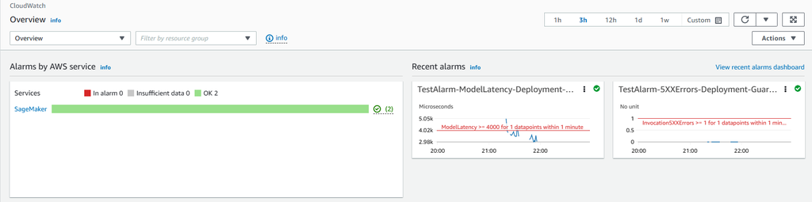

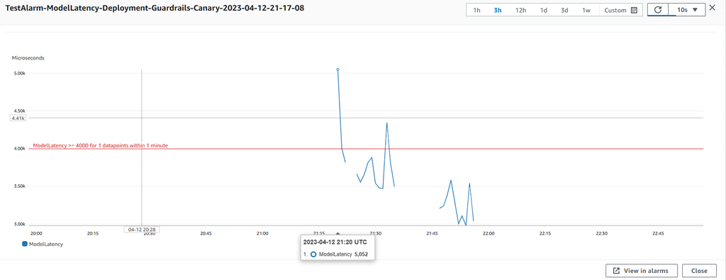

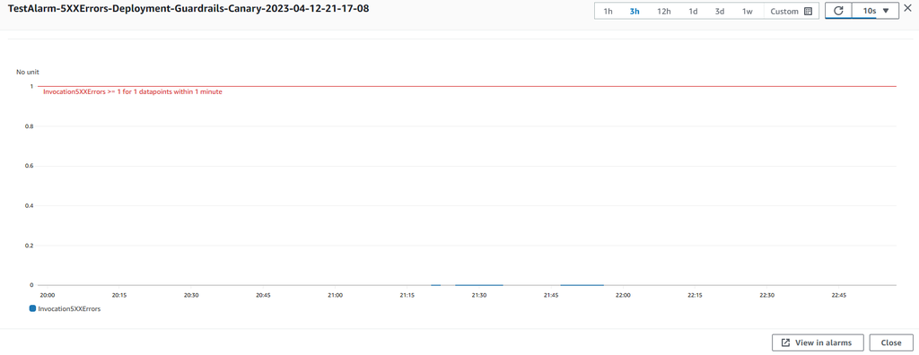

Collect the endpoint metrics during the deployment:

Below, we are going to plot graphs to show the Invocations,Invocation5XXErrors and ModelLatency against the Endpoint.

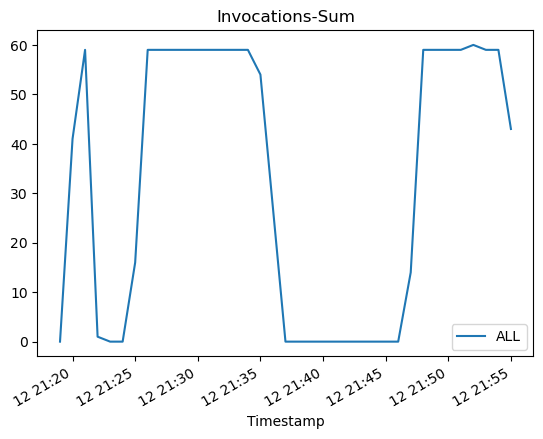

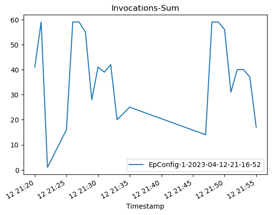

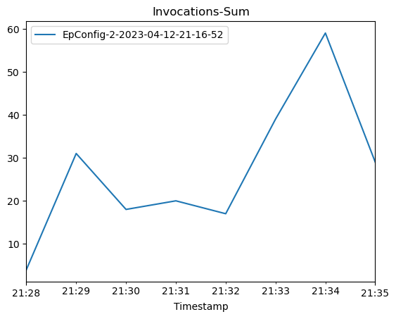

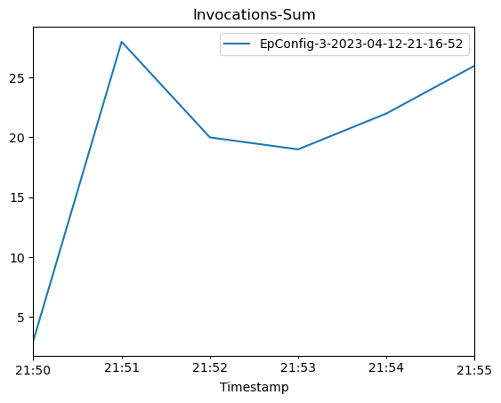

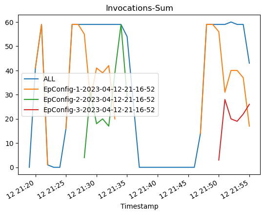

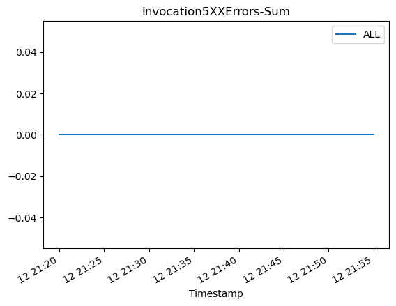

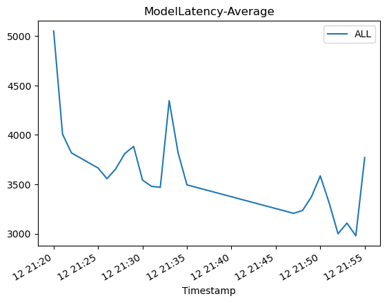

```python
invocation_metrics = plot_endpoint_invocation_metrics(
    endpoint_name, None, "AllTraffic", "Invocations", "Sum"
)
metrics_epc_1 = plot_endpoint_invocation_metrics(
    endpoint_name, ep_config_name, "AllTraffic", "Invocations", "Sum"
)
metrics_epc_2 = plot_endpoint_invocation_metrics(
    endpoint_name, ep_config_name2, "AllTraffic", "Invocations", "Sum"
)
metrics_epc_3 = plot_endpoint_invocation_metrics(
    endpoint_name, ep_config_name3, "AllTraffic", "Invocations", "Sum"
)

metrics_all = invocation_metrics.join([metrics_epc_1, metrics_epc_2, metrics_epc_3], how="outer")
metrics_all.plot(title="Invocations-Sum")

invocation_5xx_metrics = plot_endpoint_invocation_metrics(
    endpoint_name, None, "AllTraffic", "Invocation5XXErrors", "Sum"
)
model_latency_metrics = plot_endpoint_invocation_metrics(
    endpoint_name, None, "AllTraffic", "ModelLatency", "Average"
)
```

The Amazon CloudWatch metrics for the total invocations for each endpoint config shows how invocation requests are shifted from the old version to the new version during deployment.

You can now safely update your endpoint and monitor model regressions during deployment and trigger auto-rollback action.

### NOTE: You need the models (Not endpoint) for Shadow Testing. Do not clean them now, until you are done with next section

# SageMaker shadow testing overview

Amazon SageMaker now enables you to evaluate any changes to your model serving infrastructure, consisting of the ML model, the serving container, or the ML instance by shadow testing its performance against the currently deployed one. Shadow testing can help you catch potential configuration errors and performance issues before they impact end users. With SageMaker, you don’t need to invest in building your own shadow testing infrastructure, allowing you to focus on model development.

You can use this to validate changes to any component to your production variant, namely the model, the container, or the instance, without any end user impact. It is useful in situations such as:

- You are considering promoting a new model that has been validated offline to production but want to evaluate operational performance metrics such as latency, error rate before making this decision
- You are considering changes to your serving infrastructure container, such as patching vulnerabilities or upgrading to newer versions, and want to assess the impact of these changes prior to promotion
- You are considering changing your ML instance and want to evaluate how the new instance would perform with live inference requests.

Just select a production variant you want to test against, and SageMaker automatically deploys the new variant in shadow mode and routes a copy of the inference requests to it in real time within the same endpoint. Only the responses of the production variant are returned to the calling application. You can choose to discard or log the responses of the shadow variant for offline comparison.

This notebook provides a walkthrough of the feature using the SageMaker Inference APIs.

[figure not shown]

A production variant consists of the ML model, Serving Container, and ML Instance. Since each variant is independent of others, you can have different models, containers, or instance types across variants. SageMaker lets you specify autoscaling policies on a per-variant basis so they can scale independently based on incoming load. SageMaker supports up to 10 production variants per endpoint. You can either configure a variant to receive a portion of the incoming traffic by setting variant weights or specify the target variant in the incoming request. The response from the production variant is forwarded back to the invoker.

A shadow variant (new) has the same components as a production production variant. A user specified portion of the requests, known as the traffic sampling percentage (VariantWeight parameter in the ShadowProductionVariants object), is forwarded to the shadow variant. You can choose to log the response of the shadow variant in S3 or discard it. For an endpoint with a shadow variant, you can have a maximum of one production variant.

You can monitor the invocation metrics for both production and shadow variants in CloudWatch under the AWS/SageMaker namespace

# Setup

```python
!pip install sagemaker --quiet
!pip install -U awscli --quiet
```

```python
import os
import boto3
import sagemaker
import time
from time import gmtime, strftime
from datetime import datetime, timedelta, timezone
from sagemaker import get_execution_role, session
from sagemaker.s3 import S3Downloader, S3Uploader

boto_session = boto3.session.Session()
role = sagemaker.get_execution_role()
region = boto3.Session().region_name
sm_session = session.Session(boto3.Session())
sm = boto3.Session().client("sagemaker")
sm_runtime = boto3.Session().client("sagemaker-runtime")

bucket = sagemaker.Session().default_bucket()

prefix = "sagemaker/shadow-deployment"
resource_name = "ShadowFinalProj-nr-{}-{}"
```

# Deploy the two models as production and shadow variants to a real-time Inference endpoint

```python
model_name = 'xgb-food-pred-2023-04-12-21-16-07'
model_name2 = 'xgb-food-pred3-2023-04-12-21-16-07'
```

The first step in deploying a trained model to SageMaker Inference is to created a SageMaker Model using the create_model API

The next step is to create an endpoint config with the production and shadow variants. The ProductionVariants and the ShadowProductionVariants are of particular interest. We set the InitialVariantWeight in the ShadowProductionVariants to sample and send 50% of the production variant requests to the shadow variant. The production variant receives 100% of the traffic.

```python
ep_config_name = f"Shadow-EpConfig-{datetime.now():%Y-%m-%d-%H-%M-%S}"
production_variant_name = "production"
shadow_variant_name = "shadow"

create_endpoint_config_response = sm.create_endpoint_config(
    EndpointConfigName=ep_config_name,
    ProductionVariants=[
        {
            "VariantName": production_variant_name,
            "ModelName": model_name,
            "InstanceType": "ml.m5.xlarge",
            "InitialInstanceCount": 2,
            "InitialVariantWeight": 1,
        }
    ],
    ShadowProductionVariants=[
        {
            "VariantName": shadow_variant_name,
            "ModelName": model_name2,
            "InstanceType": "ml.m5.xlarge",
            "InitialInstanceCount": 1,
            "InitialVariantWeight": 0.5,
        }
    ],
)
print(f"Created EndpointConfig: {create_endpoint_config_response['EndpointConfigArn']}")
```

```
Created EndpointConfig: arn:aws:sagemaker:us-east-1:731623272175:endpoint-config/shadow-epconfig-2023-04-12-22-27-58
```

```python
endpoint_name = f"nr-xgb-prod-shadow-{datetime.now():%Y-%m-%d-%H-%M-%S}"
create_endpoint_api_response = sm.create_endpoint(
    EndpointName=endpoint_name,
    EndpointConfigName=ep_config_name,
)
```

Now, wait for the endpoint creation to complete. This should take 2-5 minutes, depending on your model artifact and serving container size.

```python
def wait_for_endpoint_in_service(endpoint_name):
    print("Waiting for endpoint in service")
    while True:
        details = sm.describe_endpoint(EndpointName=endpoint_name)
        status = details["EndpointStatus"]
        if status in ["InService", "Failed"]:
            print("\nDone!")
            break
        print(".", end="", flush=True)
        time.sleep(30)


wait_for_endpoint_in_service(endpoint_name)

sm.describe_endpoint(EndpointName=endpoint_name)
```

```
Waiting for endpoint in service

Done!
```

```
{'EndpointName': 'nr-xgb-prod-shadow-2023-04-12-22-28-50',
 'EndpointArn': 'arn:aws:sagemaker:us-east-1:731623272175:endpoint/nr-xgb-prod-shadow-2023-04-12-22-28-50',
 'EndpointConfigName': 'Shadow-EpConfig-2023-04-12-22-27-58',
 'ProductionVariants': [{'VariantName': 'production',
   'DeployedImages': [{'SpecifiedImage': '683313688378.dkr.ecr.us-east-1.amazonaws.com/sagemaker-xgboost:0.90-1-cpu-py3',
     'ResolvedImage': '683313688378.dkr.ecr.us-east-1.amazonaws.com/sagemaker-xgboost@sha256:4814427c3e0a6cf99e637704da3ada04219ac7cd5727ff62284153761d36d7d3',
     'ResolutionTime': datetime.datetime(2023, 4, 12, 22, 28, 51, 539000, tzinfo=tzlocal())}],
   'CurrentWeight': 1.0,
   'DesiredWeight': 1.0,
   'CurrentInstanceCount': 2,
   'DesiredInstanceCount': 2}],
 'EndpointStatus': 'InService',
 'CreationTime': datetime.datetime(2023, 4, 12, 22, 28, 50, 984000, tzinfo=tzlocal()),
 'LastModifiedTime': datetime.datetime(2023, 4, 12, 22, 31, 0, 794000, tzinfo=tzlocal()),
 'ShadowProductionVariants': [{'VariantName': 'shadow',
   'DeployedImages': [{'SpecifiedImage': '683313688378.dkr.ecr.us-east-1.amazonaws.com/sagemaker-xgboost:0.90-2-cpu-py3',
     'ResolvedImage': '683313688378.dkr.ecr.us-east-1.amazonaws.com/sagemaker-xgboost@sha256:0d098653ff2915993d61180da0cde0ed982805093463d40f30212b8050486f18',
     'ResolutionTime': datetime.datetime(2023, 4, 12, 22, 28, 51, 604000, tzinfo=tzlocal())}],
   'CurrentWeight': 0.5,
   'DesiredWeight': 0.5,
   'CurrentInstanceCount': 1,
   'DesiredInstanceCount': 1}],
 'ResponseMetadata': {'RequestId': 'd1d629ae-0faf-418f-a97b-1e980c873c63',
  'HTTPStatusCode': 200,
  'HTTPHeaders': {'x-amzn-requestid': 'd1d629ae-0faf-418f-a97b-1e980c873c63',
   'content-type': 'application/x-amz-json-1.1',
   'content-length': '1214',
   'date': 'Wed, 12 Apr 2023 22:32:05 GMT'},
  'RetryAttempts': 0}}
```

# Invoke Endpoint

```python
import time
def invoke_endpoint(
    endpoint_name, max_invocations=600, wait_interval_sec=1, should_raise_exp=False
):
    print(f"Sending test traffic to the endpoint {endpoint_name}. \nPlease wait...")

    count = 0
    with open("test_data/marketinganalytics_food_finalproject.csv", "r") as f:
        for row in f:
            payload = row.rstrip("\n")
            try:
                response = sm_runtime.invoke_endpoint(
                    EndpointName=endpoint_name, ContentType="text/csv", Body=payload
                )
                response["Body"].read()
                print(".", end="", flush=True)
            except Exception as e:
                print("E", end="", flush=True)
                if should_raise_exp:
                    raise e
            count += 1
            if count > max_invocations:
                break
            time.sleep(wait_interval_sec)

    print("\nDone!")


invoke_endpoint(endpoint_name, max_invocations=100)
```

```
Sending test traffic to the endpoint nr-xgb-prod-shadow-2023-04-12-22-28-50.
Please wait...
.....................................................................................................
Done!
```

Now that the endpoint is InService and has been invoked, the following cells help collect CloudWatch metrics between the production and shadow variants for metrics comparison.

```python
%matplotlib inline
```

```python
import pandas as pd

cw = boto3.Session().client("cloudwatch", region_name=region)


def get_sagemaker_metrics(
    endpoint_name,
    variant_name,
    metric_name,
    statistic,
    start_time,
    end_time,
):
    dimensions = [
        {"Name": "EndpointName", "Value": endpoint_name},
        {"Name": "VariantName", "Value": variant_name},
    ]
    namespace = "AWS/SageMaker"
    if metric_name in ["CPUUtilization", "MemoryUtilization", "DiskUtilization"]:
        namespace = "/aws/sagemaker/Endpoints"

    metrics = cw.get_metric_statistics(
        Namespace=namespace,
        MetricName=metric_name,
        StartTime=start_time,
        EndTime=end_time,
        Period=1,
        Statistics=[statistic],
        Dimensions=dimensions,
    )

    if len(metrics["Datapoints"]) == 0:
        return
    return (
        pd.DataFrame(metrics["Datapoints"])
        .sort_values("Timestamp")
        .set_index("Timestamp")
        .drop(["Unit"], axis=1)
        .rename(columns={statistic: variant_name})
    )


def plot_endpoint_invocation_metrics(
    endpoint_name,
    metric_name,
    statistic,
    start_time=None,
):
    start_time = start_time or datetime.now(timezone.utc) - timedelta(minutes=10)
    end_time = datetime.now(timezone.utc)
    metrics_production = get_sagemaker_metrics(
        endpoint_name,
        production_variant_name,
        metric_name,
        statistic,
        start_time,
        end_time,
    )
    metrics_shadow = get_sagemaker_metrics(
        endpoint_name,
        shadow_variant_name,
        metric_name,
        statistic,
        start_time,
        end_time,
    )
    try:
        metrics_variants = pd.merge(metrics_production, metrics_shadow, on="Timestamp")
        return metrics_variants.plot(y=["production", "shadow"])
    except Exception as e:
        print(e)
```

# Metric Comparison

Now that we have deployed both the production and shadow models, let us compare the invocation metrics. Here is a list of invocation metrics available for comparison. Let us start by comparing invocations between the production and shadow variants

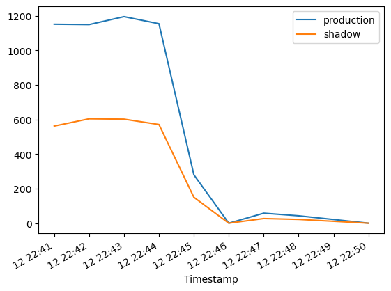

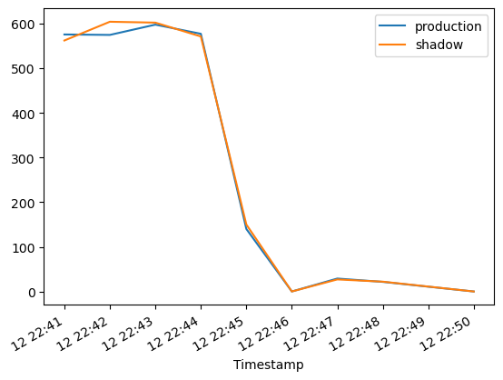

```python
invocations = plot_endpoint_invocation_metrics(endpoint_name, "Invocations", "Sum")
invocations_per_instance = plot_endpoint_invocation_metrics(
    endpoint_name, "InvocationsPerInstance", "Sum"
)
```

The Invocation metric refers to the number of invocations sent to the production variant. A fraction of these invocations, specified in the variant weight, are sent to the shadow variant. The invocation per instance is calculated by dividing the total number of invocations by the number of instances in a variant. From the chart above, we can confirm that both the production and shadow variants are receiving invocation requests according to the weights specified in the endpoint config.

Next let us compare the model latency between the production and shadow variants. Model latency is the time taken by a model to respond as viewed from SageMaker.

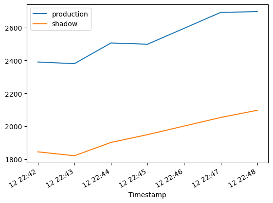

```python
model_latency = plot_endpoint_invocation_metrics(endpoint_name, "ModelLatency", "Average")
```

Using the chart above, we can observe how the model latency of the shadow variant compares with the production variant without exposing end users to the shadow variant.

We expect the overhead latency to be comparable across production and shadow variants. Overhead latency is the interval measured from the time SageMaker receives the request until it returns a response to the client, minus the model Latency.

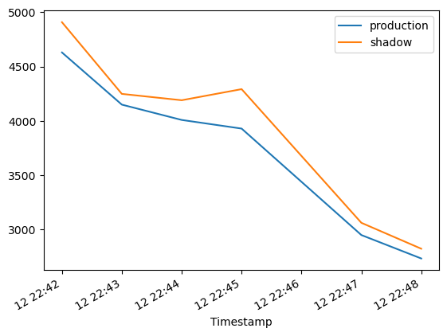

```python
overhead_latency = plot_endpoint_invocation_metrics(endpoint_name, "OverheadLatency", "Average")
```

Finally, let us review the 4xx, 5xx and total model errors returned by the model serving container.

```python
Invocation4xxErrors = plot_endpoint_invocation_metrics(endpoint_name, "Invocation4XXErrors", "Sum")
Invocation5xxErrors = plot_endpoint_invocation_metrics(endpoint_name, "Invocation5XXErrors", "Sum")
Invocation5xxErrors = plot_endpoint_invocation_metrics(
    endpoint_name, "InvocationModelErrors", "Sum"
)
```

[output not shown]

We can consider promoting the shadow model if we do not see any differences in 4xx and 5xx errors between the production shadow variants.

To promote the shadow model to production, create a new endpoint configuration with current ShadowProductionVariant as the new ProductionVariant and removing the ShadowProductionVariant. This will remove the current ProductionVariant and promote the shadow variant to become the new production variant. As always, all SageMaker updates are orchestrated as blue/green deployments under the hood and there is no loss of availability while performing the update. Optionally, you can leverage Deployment Guardrails if you want to use all-at-once traffic shifting and auto rollbacks during your update.

```python
promote_ep_config_name = f"PromoteShadow-EpConfig-{datetime.now():%Y-%m-%d-%H-%M-%S}"

create_endpoint_config_response = sm.create_endpoint_config(
    EndpointConfigName=promote_ep_config_name,
    ProductionVariants=[
        {
            "VariantName": shadow_variant_name,
            "ModelName": model_name2,
            "InstanceType": "ml.m5.xlarge",
            "InitialInstanceCount": 2,
            "InitialVariantWeight": 1.0,
        }
    ],
)
print(f"Created EndpointConfig: {create_endpoint_config_response['EndpointConfigArn']}")
```

```
Created EndpointConfig: arn:aws:sagemaker:us-east-1:731623272175:endpoint-config/promoteshadow-epconfig-2023-04-12-22-52-50
```

```python
update_endpoint_api_response = sm.update_endpoint(
    EndpointName=endpoint_name,
    EndpointConfigName=promote_ep_config_name,
)

wait_for_endpoint_in_service(endpoint_name)

sm.describe_endpoint(EndpointName=endpoint_name)
```

```
Waiting for endpoint in service
.....
Done!
```

```
{'EndpointName': 'nr-xgb-prod-shadow-2023-04-12-22-28-50',
 'EndpointArn': 'arn:aws:sagemaker:us-east-1:731623272175:endpoint/nr-xgb-prod-shadow-2023-04-12-22-28-50',
 'EndpointConfigName': 'PromoteShadow-EpConfig-2023-04-12-22-52-50',
 'ProductionVariants': [{'VariantName': 'shadow',
   'DeployedImages': [{'SpecifiedImage': '683313688378.dkr.ecr.us-east-1.amazonaws.com/sagemaker-xgboost:0.90-2-cpu-py3',
     'ResolvedImage': '683313688378.dkr.ecr.us-east-1.amazonaws.com/sagemaker-xgboost@sha256:0d098653ff2915993d61180da0cde0ed982805093463d40f30212b8050486f18',
     'ResolutionTime': datetime.datetime(2023, 4, 12, 22, 53, 5, 528000, tzinfo=tzlocal())}],
   'CurrentWeight': 1.0,
   'DesiredWeight': 1.0,
   'CurrentInstanceCount': 2,
   'DesiredInstanceCount': 2}],
 'EndpointStatus': 'InService',
 'CreationTime': datetime.datetime(2023, 4, 12, 22, 28, 50, 984000, tzinfo=tzlocal()),
 'LastModifiedTime': datetime.datetime(2023, 4, 12, 22, 55, 19, 744000, tzinfo=tzlocal()),
 'ResponseMetadata': {'RequestId': '7a58ec91-7cb9-4101-857d-557dabdc9fac',
  'HTTPStatusCode': 200,
  'HTTPHeaders': {'x-amzn-requestid': '7a58ec91-7cb9-4101-857d-557dabdc9fac',
   'content-type': 'application/x-amz-json-1.1',
   'content-length': '768',
   'date': 'Wed, 12 Apr 2023 22:55:36 GMT'},
  'RetryAttempts': 0}}
```

If you do not want to create multiple endpoint configurations and want SageMaker to manage the end to end workflow of creating, managing, and acting on the results of the shadow tests, consider using the SageMaker Inference Experiement APIs/Console experience. As stated earlier, they enable you to setup shadow tests for a predefined duration of time, monitor the progress through a live dashboard, presents clean up options upon completion, and act on the results. To get started, please navigate to the ‘Shadow Tests’ section of the SageMaker Inference console.

# Cleanup

If you do not plan to use this endpoint further, you should delete the endpoint to avoid incurring additional charges and clean up other resources created in this notebook.

```python
sm.delete_endpoint(EndpointName=endpoint_name)
```

[output not shown]